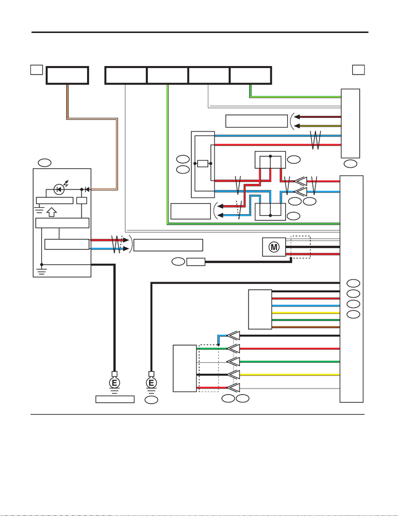

WI-159

Electric Power Steering System

WIRING SYSTEM

18.Electric Power Steering System

A: WIRING DIAGRAM

4

2

1

5

3

WI-44360

a a

GAP

B40

B450

A:

B452

B:

PS1

C:

B281

B:

i84

C:

PS2

D:

B451PS3

PS4

i10

STEERING

I/F

I/F

W16

R6

L

R

L14

B20

B28

G/Y 8

B/R 5

B/Y 4

BB1

G/Y A1

LA7

1R

1

1

1L

1

1

RA6

L

L

R

C35

RC27

WB2

B

R

G

Y

W

A3

A4

A5

A9

A10

B

R

G

Y

W

L

G

W

B

R

C4

C3

C2

C1

C6

B

R

L

Y

G

C5BR

B

D1

D2

D3

W

B

R

BR/W20

38

B

33 R

L32

1

W

G/Y

W

G/Y

B

BR/W

B

BAT-1

(B)

6

7

i229 B551

i233

i232

1

MICRO COMPUTER

CAN TRANSCEIVER &

RECEIVER

DRIVE CIRCUIT

POWER STEERING

BRACKET GROUND

BODY

INTEGRATED

UNIT

MOTOR

POWER STEERING CM

RESOLVER

SENSOR

TORQUE SENSOR

DATA LINK

CONNECTOR

FB-44

F/B FUSE NO. 33

(IG)

FB-32

F/B FUSE NO. 4

(IG)

MB-27

M/B FUSE NO. 13

(B)

FB-12

F/B FUSE NO. 2

(IG)

REF. TO ENGINE ELECTRICAL

SYSTEM [1g] [2g]

REF. TO CAN COMMUNICATION

SYSTEM [b]

REF. TO CAN

COMMUNICATION

SYSTEM [b]

REF. TO GND [e]

COMBINATION

METER

J/C

J/C

: TERMINAL No. OPTIONAL ARRANGEMENT

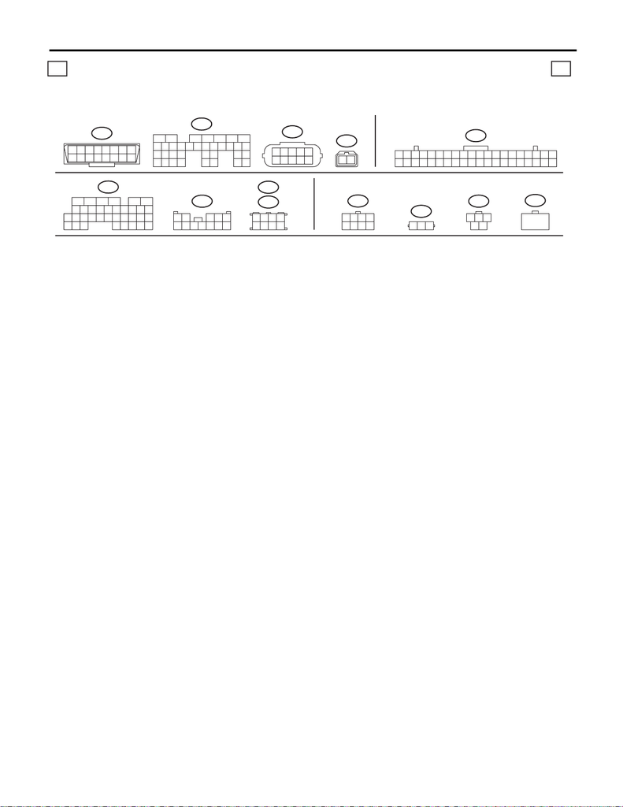

WI-160

Electric Power Steering System

WIRING SYSTEM

LIST OF CONNECTORS

b b

B450

B452

B40

B:

i10

(B)

(B)

(B)

A:

1

9

8

16

2

10

7

15

3

11

6

14

4

12

5

13

9

10

78

5

6

34

2

1

21

11 12

9

10

2

15 1613 14 19

18

20

21 22 23 24 26

25

17

PS1

C:

(B)

3412

7856

PS2

D:

(B)

312

PS3

(GR)

123

45

PS4

(B)

1

WI-44361

B281B:

29

10 11 12 13 14 15

2524

16

30

98

17 18 19

20

28

21 22 23

3231

26 27

33 34 35

i84C:

19

18

21

20

2322 24 25 26

17

1

23

4

56

27

28 29 30

31 32 33 34 35

798

151413121110 16

i229

12 345

6789

10 11 12

i233

i232

78

5

6

34

21

[figure not shown]

Electric Power Steering System

WIRING SYSTEM